# Link daily IDs of same visitor

Based on that assumption, I extract the results of the Fujisan area. However, the result is not good again:

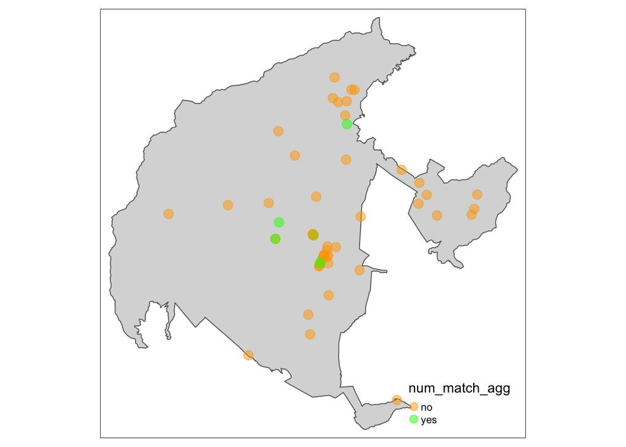

```r
tm_shape(nps.yamashizu) +
  tm_polygons() +
  tm_shape(match.log.nps.firstday) +
  tm_dots(col = "num_match_agg", size = 0.5, alpha = 0.5,
          palette = c(yes = "green", no = "orange"))
```

So, that is results of the first day (to match the daily IDs of the second day to the daily IDs of the first day) … what if we try the second day?

Unfortunately, bomb again:

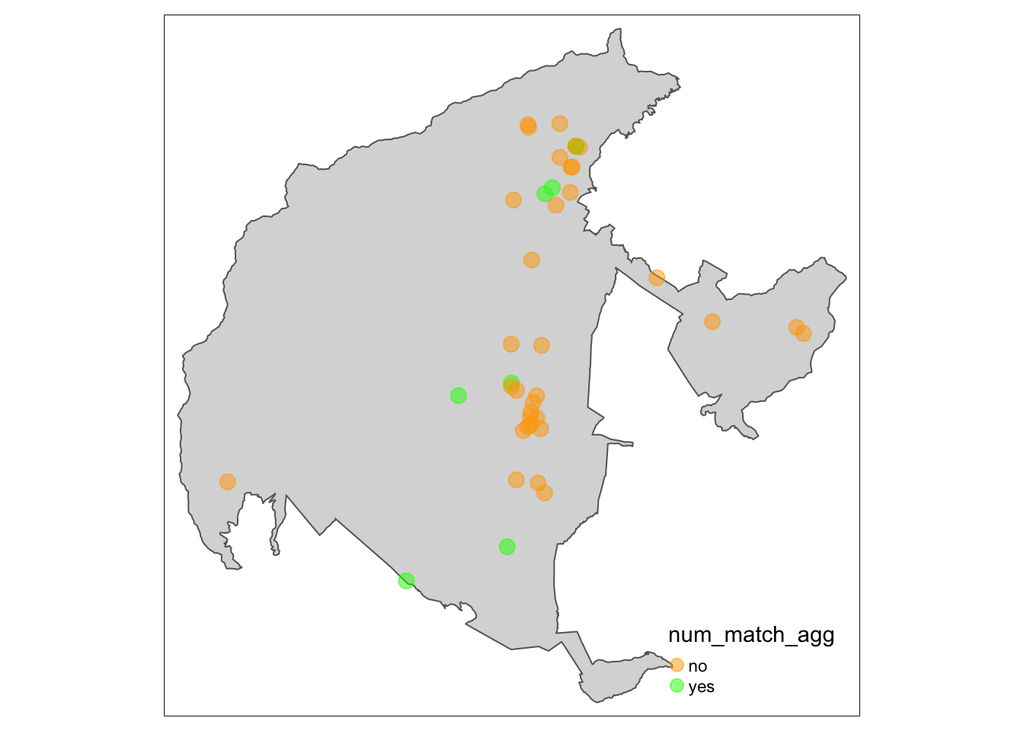

```r
tm_shape(nps.yamashizu) +
  tm_polygons() +
  tm_shape(match.log.nps) +
  tm_dots(col = "num_match_agg", size = 0.5, alpha = 0.5,
          palette = c(yes = "green", no = "orange"))
```

## Conclusion

As you can see, the results were not good: for many visitors, they go to the mountain, they stay somewhere in the mountain, but we just lose their track after the first day. There are some potential way to solve the problem:

1. If Agoop company can provide some information that can help us link different daily IDs of the same visitor without breaking relate data regulation?
2. How about use the data that daily IDs of the first day can be matched with some daily IDs the next day? Of course, bias generated with that process. And the big data might become small data after that.
3. Can we use daily ID rather than trying to figure out the unique “visitor ID”? It is kind of like when doing biodiversity research, it would be better if we have both species and abundance data (that we can calculate some fancy biodiversity index). But the abundance data is not usually available, then we just use the species number data - both biodiversity index and species number are indicator to our target measurement (which is “biodiversity”). Or, put it another way, if we want to do research on animals’ food with their body size, our target measurement is “body size”, we can use either “height” or “weight” to indicate that measurement.
4. How did you deal with it when analyzing the Fujisan mesh data in previous report (section “3 施策評価の統計分析” of 京都大学, 北海道大学, 甲南大学, 国立環境研究所, n.d. 我が国における自然環境施策への効果的な資源動員に向けた研究研究報告書)?

It is really a tough challenge. I need more time to think about that.